# The Use of Convolutional Neural Networks in Melanoma Detection

### Kyla Perkinson, Spring 2023

## Introduction

### Motivation

Melanoma is the most common form of skin cancer for 25-29 year olds, and the second most common form of skin cancer for 15-19 year olds. Despite these alarming statistics, only about 16% of Americans between the ages of 18-29 years old visited a dermatologist in 2018. Even though melanoma is the deadliest form of skin cancer, the survival rate is 93% when it is detected in early stages.

Access to dermatologists is also a concern. Factors such as cost, hours of operation, and availability of appointments add to the lack of annual visits. A more accessible way for the general public to determine their risk for melanoma would significantly improve the chances of it being caught in earlier stages and thus increase survival rates.

In 2018, a [study](https://www.sciencedirect.com/science/article/pii/S0923753419341055) was done in which 58 dermatologists with varying backgrounds and expertise were measured on their sensitivity and specificity for melanoma classification. When using dermoscopy only, these dermatologists had an average sensitivity of 86.6% and specificity of 71.3%. In the scope of this study, the sensitivity is how many patients with melanoma were diagnosed with it, and specificity is how many patients that do not have melanoma were accurately given negative results.

With this project, I hope to demonstrate how a machine learning model, specifically a convolutional neural network, can be used in the detection of melanoma. Specifically, my goal is to develop a model that outperforms a sensitivity of 86.6% and specificity of 71.3%, as this would be an improvement from the dermatologists' diagnoses mentioned previously. I believe that machine learning models could someday be used not only in melanoma diagnosis, but the diagnosis of other cancers as well. This would provide the general public with an accessible resource in cancer detection.

### Required Libraries

I will be using the following libraries throughout this project. More information can be found in their documentation linked below:

- [torch](https://pytorch.org/docs/stable/index.html)
- [torchvision](https://pytorch.org/vision/stable/index.html)
- [numpy](https://numpy.org/doc/stable/)
- [matplotlib](https://matplotlib.org/stable/index.html)
- [sklearn](https://scikit-learn.org/stable/user_guide.html)
- [pandas](https://pandas.pydata.org/docs/)

```python
import torch
import torch.nn as nn
from torchvision import datasets, transforms
import torchvision.transforms.functional as F
from torch.utils.data import Dataset, DataLoader, Subset

import numpy as np
import matplotlib.pyplot as plt
import matplotlib.gridspec as gridspec

from sklearn.metrics import precision_score, recall_score, f1_score
from sklearn.metrics import confusion_matrix, ConfusionMatrixDisplay
import pandas as pd
```

## Data Collection and Processing

### The Dataset

The dataset that I will be using can be found [here](https://www.kaggle.com/datasets/hasnainjaved/melanoma-skin-cancer-dataset-of-10000-images). This dataset contains 10,605 images of moles that are either malignant or benign. The dataset is split almost 50/50, with 5,500 benign images and 5,105 malignant images. Each image is 3x300x300 but will be resized to 1x96x96 to make training, validation, and testing faster. This downsampling will cause information loss, so with more time it would be beneficial to keep the images at the original size to prevent this loss of information.

### Data Preprocessing

Each image will go through a number of transformations. This includes resizing the image to 3x96x96, center cropping it, grayscaling it, which results in resizing to 1x96x96, and normalizing the image to have a mean of 0 and standard deviation of 1. Normalization will make sure each feature has a similar range and thus improve the performance of the model.

```python
transform = transforms.Compose([transforms.Resize((96, 96)),
                               transforms.CenterCrop(96),
                               transforms.Grayscale(),
                               transforms.ToTensor(),
                               transforms.Normalize(mean=[0], std=[1])])

# creating datasetes from the folders
train_dataset = datasets.ImageFolder('./data/train', transform=transform)
val_dataset = datasets.ImageFolder('./data/validation', transform=transform)
test_dataset = datasets.ImageFolder('./data/test', transform=transform)
```

PyTorch's ImageFolder class has a `class_to_index` function that prints out the classes and corresponding labels for the data. Using this, I can see that a benign image is labeled 0 and a malignant image is labeled 1.

```python
print(train_dataset.class_to_idx)
```

```
{'benign': 0, 'malignant': 1}
```

I am now going to define three hyperparameters for my model: batch size, learning rate, and the number of epochs. Batch size determines how many examples are sampled at once before updating the model's parameters. Learning rate is how much a model updates its parameters with respect to the loss gradient descent. A larger learning rate means the model would uppdate its parameters by larger values, however if the learning rate is too high it could hinder the model's performance by missing the minima and therefore not converging. A smaller learning rate means the model would update its parameters by smaller values, however if the learning rate is too small it could take too long to train the model. Lastly, the number of epochs is how many iterations the model trains on.

To start, I am going to use a batch size of 16, learning rate of 0.001, and number of epochs as 50. These will be updated if necessary.

```python
batch_size = 16
learning_rate = 0.001
num_epochs = 50
```

PyTorch's `DataLoader` class allows the datasets to be iterated through based on batch size. I will have a dataloader for each dataset, so training, validation, and testing, in which the data will be split by batch size. The training dataloader will also shuffle the data so that each batch will be representative of the entire dataset and therefore prevent overfitting.

```python
train_dataloader = DataLoader(train_dataset, batch_size=batch_size, shuffle=True)
val_dataloader = DataLoader(val_dataset, batch_size=batch_size, shuffle=False)
test_dataloader = DataLoader(test_dataset, batch_size=batch_size, shuffle=False)
```

Before developing the model, I am going to plot a batch of images with their corresponding labels to get a better understanding of the datset.

```python
def show(images, labels):
    fig, axs = plt.subplots(ncols=4, nrows=4, squeeze=False)
    for i in range(images.shape[0]):
        image = images[i]
        image = F.to_pil_image(image)
        axs[int(i / 4), i % 4].imshow(np.asarray(image), cmap='gray')
        axs[int(i / 4), i % 4].set(xticklabels=[], yticklabels=[], xticks=[], yticks=[])
        title = "Malignant"
        if labels[i].item() == 0:
            title = "Benign"
        axs[int(i / 4), i % 4].set_title(title, fontsize=8)
```

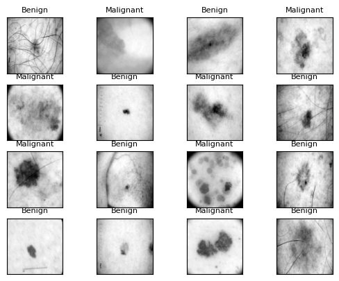

```python
images, labels = next(iter(train_dataloader))
show(images, labels)
```

## Building a Convolutional Neural Network

I will now begin developing the convolutional neural network. Convolutional neural networks typically have convolutional layers, pooling layers, and fully connected layers. Convolutional layers extract features from the input and pass them through an activation function, typically ReLU. Pooling layers reduce dimensionality by splitting up the feature map into patches and either keeping the maximum value from each patch (max pooling) or keeping the average value of the patch (average pooling). The output from the last max pooling layer is flattened and passed to fully connected layers. The output of the last fully connected layer is the input for sigmoid, which returns the probabilities for each class.

The architecture for the convolutional neural network I will be implementing includes two convolutional layers, each followed by ReLU and a max pooling layer, then two fully connected layers, with the first being followed by ReLU and the last being followed by sigmoid to output a value between 0 and 1. This output then predicts what class the image is. If the output is less than or equal to 0.5 the image will classified as benign, and if it is greater than 0.5 it will be classified as malignant.

```python
class CNN(nn.Module):
    def __init__(self):
        super(CNN, self).__init__()

        # defining convolutional layers
        self.conv1 = nn.Conv2d(in_channels=1, out_channels=16, kernel_size=3, stride=1, padding=1)
        self.conv2 = nn.Conv2d(in_channels=16, out_channels=32, kernel_size=3, stride=1, padding=1)

        # defining activation functions and max pool
        self.relu = nn.ReLU()
        self.sigmoid = nn.Sigmoid()
        self.maxpool = nn.MaxPool2d(2,2)

        # defining fully connected layers
        self.linear1 = nn.Linear(18432, 120)
        self.linear2 = nn.Linear(120, 1)

    def forward(self, x):
        x = self.conv1(x)
        x = self.relu(x)
        x = self.maxpool(x)

        x = self.conv2(x)
        x = self.relu(x)
        x = self.maxpool(x)

        x = torch.flatten(x, 1)

        x = self.linear1(x)
        x = self.relu(x)

        x = self.linear2(x)
        x = self.sigmoid(x)

        return x
```

To decrease training time, I am going to be using a GPU to train the model. PyTorch has built-in CUDA support which makes it easier to assign a model to the GPU device being used. Since I am going to be moving the model to the GPU, I also need to move my input to the GPU, which will be done during the training. In the code below, I am using `.cuda()` to move the model to the GPU.

```python
model_original = CNN()
model_original.cuda()
```

```
CNN(
  (conv1): Conv2d(1, 16, kernel_size=(3, 3), stride=(1, 1), padding=(1, 1))
  (conv2): Conv2d(16, 32, kernel_size=(3, 3), stride=(1, 1), padding=(1, 1))
  (relu): ReLU()
  (sigmoid): Sigmoid()
  (maxpool): MaxPool2d(kernel_size=2, stride=2, padding=0, dilation=1, ceil_mode=False)
  (linear1): Linear(in_features=18432, out_features=120, bias=True)
  (linear2): Linear(in_features=120, out_features=1, bias=True)
)
```

Next I am defining the loss function and optimizer I will be using during training. Image classification problems most commonly use cross entropy loss, so I will be using the binary cross entropy loss function since I am working with two classes. I will also be using Adam as the optimizer, which updates the model's parameters based on a batch of training data instead of the entire dataset. This can also make the model converge faster and therefore decrease training time. I am choosing to use Adam because of its use of an adaptive learning rate. With standard stochastic gradient descent, a single learning rate is used throughout. With Adam, the learning rate is adapted based on gradients so that the model converges faster.

```python
loss_function = nn.BCELoss()
optim = torch.optim.Adam(model_original.parameters(), lr = learning_rate)
```

Now that the model, loss function, and optimizer are defined, I am going to be implementing the training and validation loops.

Training a neural network consists of forward and backward propogation. Weights and biases are defined for each layer. During forward propogation, the data is fed in batches through the network and the output for each layer is calculated by the weights and biases. After forward propogation, the loss function is used to calculate the error between the predicted and ground truth labels. Then, backward propogation computes the gradients of the loss function with respect to the weights and biases. The gradients are fed backwards through the network, updating the weights and biases at each layer based on the gradients and learning rate to minimize the error.

The validation data is then used to see how well the model can generalize what it learned during training to a new dataset. If the model performs significantly better on the training set than the validation set, it means the model is overfitting and learning the training set too well. This could be seen by high training accuracies but low validation accuracies, or low training loss but high validation loss. If the model performs poorly on both the training set and validation set, it means the model is underfitting and it has not learned enough patterns in the data to accurately classify the images. This could be characterized by low training and validation accuracies, or high training and validation losses. Ideally, I would like to see similar training and validation accuracies that are fairly high, with the losses for both sets decreasing significantly at first and eventually plateauing at a low value. This would indicate that the model is able to learn patterns in the data and generalize to new data.

```python
def train_model(model, num_epochs, train_dataloader, val_dataloader, optim, loss_function):
  mean_train_loss = []
  mean_val_loss = []
  mean_train_acc = []
  mean_val_acc = []

  for epoch in range(num_epochs):
      # training phase
      model.train()
      train_loss = []
      val_loss = []
      train_acc = 0.
      val_acc = 0.

      for idx, batch in enumerate(train_dataloader):
          images, labels = batch

          optim.zero_grad()

          # forward propagation
          outputs = model.forward(images.to("cuda"))

          # calculating loss
          loss = loss_function(outputs, labels.unsqueeze(1).float().to("cuda"))

          # backward propagation
          loss.backward()

          optim.step()

          train_loss.append(loss.cpu().detach().numpy())

          # determining how many images are correctly labeled by model
          for i in range(0, len(outputs)):
              output = outputs[i].item()
              label = labels[i].item()
              if round(output) == label:
                  train_acc += 1

      train_acc = train_acc / len(train_dataset)
      mean_train_acc.append(train_acc)
      mean_train_loss.append(np.mean(train_loss))

      # validation phase
      model.eval()
      for idx, batch in enumerate(val_dataloader):

          with torch.no_grad():
              images, labels = batch
              outputs = model.forward(images.to("cuda"))
              loss = loss_function(outputs, labels.unsqueeze(1).float().to("cuda"))
              val_loss.append(loss.cpu().detach().numpy())

              # determining how many images are correctly labeled by model
              for i in range(0, len(outputs)):
                  output = outputs[i].item()
                  label = labels[i].item()
                  if round(output) == label:
                      val_acc += 1

      val_acc = val_acc / len(val_dataset)
      mean_val_acc.append(val_acc)
      mean_val_loss.append(np.mean(val_loss))

      if epoch % 5 == 0:
        print("Epoch : {}, Train loss: {}, Train acc: {}, Val loss: {}, Val acc: {}".format(epoch, np.mean(train_loss), train_acc, np.mean(val_loss), val_acc))

  return mean_train_loss, mean_val_loss, mean_train_acc, mean_val_acc
```

```python
mean_train_loss, mean_val_loss, mean_train_acc, mean_val_acc = train_model(model_original, num_epochs, train_dataloader, val_dataloader, optim, loss_function)
```

```
Epoch : 0, Train loss: 0.3620978593826294, Train acc: 0.820968660968661, Val loss: 0.4057944416999817, Val acc: 0.8068627450980392
Epoch : 5, Train loss: 0.21459123492240906, Train acc: 0.914074074074074, Val loss: 0.3196569085121155, Val acc: 0.8519607843137255
Epoch : 10, Train loss: 0.14962342381477356, Train acc: 0.9405128205128205, Val loss: 0.3162722587585449, Val acc: 0.8833333333333333
Epoch : 15, Train loss: 0.08090505003929138, Train acc: 0.9725356125356125, Val loss: 0.3712203800678253, Val acc: 0.8911764705882353
Epoch : 20, Train loss: 0.03692883253097534, Train acc: 0.9881481481481481, Val loss: 0.6941648721694946, Val acc: 0.8872549019607843
Epoch : 25, Train loss: 0.018859541043639183, Train acc: 0.9941880341880341, Val loss: 0.8021795749664307, Val acc: 0.8813725490196078
Epoch : 30, Train loss: 0.008791198953986168, Train acc: 0.9969230769230769, Val loss: 0.8015453815460205, Val acc: 0.888235294117647
Epoch : 35, Train loss: 0.008565247990190983, Train acc: 0.9976068376068377, Val loss: 1.525158405303955, Val acc: 0.8813725490196078
Epoch : 40, Train loss: 0.003190251300111413, Train acc: 0.9993162393162394, Val loss: 1.4480531215667725, Val acc: 0.884313725490196
Epoch : 45, Train loss: 6.680821388727054e-05, Train acc: 1.0, Val loss: 1.6381545066833496, Val acc: 0.888235294117647
```

I am now going to plot the training and validation losses and accuracies per epoch. If both datasets have increasing accuracies and decreasing losses, it would indicate that the model is performing well.

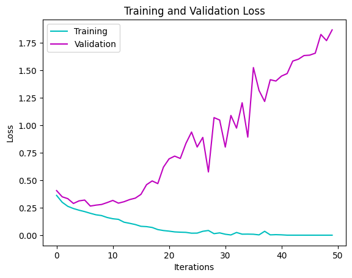

```python
plt.plot(mean_train_loss, 'c', label='Training')
plt.plot(mean_val_loss, 'm', label='Validation')
plt.ylabel('Loss')
plt.xlabel('Iterations')
plt.title('Training and Validation Loss')
plt.legend()
plt.show()
```

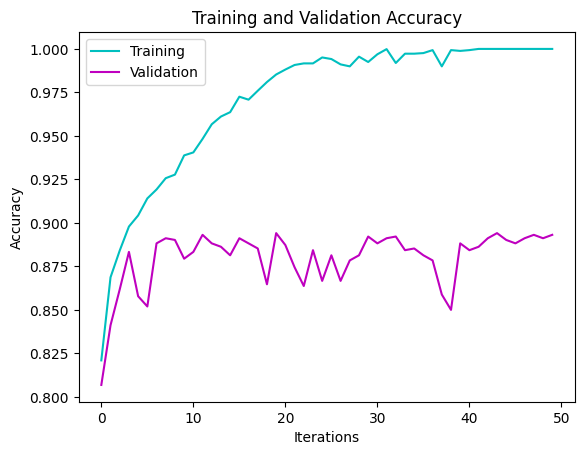

```python
plt.plot(mean_train_acc, 'c', label='Training')
plt.plot(mean_val_acc, 'm', label='Validation')
plt.ylabel('Accuracy')
plt.xlabel('Iterations')
plt.title('Training and Validation Accuracy')
plt.legend()
plt.show()
```

Both graphs show that the model is overfitting. This is indicated in the loss plots by the increase in validation loss and in the accuracy plots by the significant difference in accuracies between the training and validation data sets. Ideally, the validation loss would be decreasing and the validation accuracy would be similar to that of the training data set. There are a few updates that can be made to help prevent overfitting, which will be explored in the next section.

## Reducing Overfitting

### Adding a Dropout Layer

The first adjustment I am going to make is adding a dropout layer to the model's architecture. Adding dropout to the architecture causes neurons to be randomly dropped between layers, so the neurons are not fed to the next layer. This prevents overfitting because it the model cannot rely too heavily on one feature for classification. I am going to be adding a dropout layer after the first fully connected layer with a value of p = 0.5, which means that each neuron has a 50% chance of dropping out.

```python
class CNN_with_Dropout(nn.Module):
    def __init__(self):
        super(CNN_with_Dropout, self).__init__()

        # defining convolutional layers
        self.conv1 = nn.Conv2d(in_channels=1, out_channels=16, kernel_size=3, stride=1, padding=1)
        self.conv2 = nn.Conv2d(in_channels=16, out_channels=32, kernel_size=3, stride=1, padding=1)

        # defining activation functions and max pool
        self.relu = nn.ReLU()
        self.sigmoid = nn.Sigmoid()
        self.maxpool = nn.MaxPool2d(2,2)

        # defining fully connected layers with dropout in between
        self.linear1 = nn.Linear(18432, 120)
        self.dropout = nn.Dropout(p=0.5)
        self.linear2 = nn.Linear(120, 1)

    def forward(self, x):
        x = self.conv1(x)
        x = self.relu(x)
        x = self.maxpool(x)

        x = self.conv2(x)
        x = self.relu(x)
        x = self.maxpool(x)

        x = torch.flatten(x, 1)

        x = self.linear1(x)
        x = self.relu(x)

        x = self.dropout(x)

        x = self.linear2(x)
        x = self.sigmoid(x)

        return x
```

```python
model_dropout = CNN_with_Dropout()
model_dropout.cuda()
```

```
CNN_with_Dropout(
  (conv1): Conv2d(1, 16, kernel_size=(3, 3), stride=(1, 1), padding=(1, 1))
  (conv2): Conv2d(16, 32, kernel_size=(3, 3), stride=(1, 1), padding=(1, 1))
  (relu): ReLU()
  (sigmoid): Sigmoid()
  (maxpool): MaxPool2d(kernel_size=2, stride=2, padding=0, dilation=1, ceil_mode=False)
  (linear1): Linear(in_features=18432, out_features=120, bias=True)
  (dropout): Dropout(p=0.5, inplace=False)
  (linear2): Linear(in_features=120, out_features=1, bias=True)
)
```

```python
batch_size = 16
learning_rate = 0.001
num_epochs = 50
```

```python
train_dataloader = DataLoader(train_dataset, batch_size=batch_size, shuffle=True)
val_dataloader = DataLoader(val_dataset, batch_size=batch_size, shuffle=False)
test_dataloader = DataLoader(test_dataset, batch_size=batch_size, shuffle=False)
```

```python
loss_function = nn.BCELoss()
optim = torch.optim.Adam(model_dropout.parameters(), lr = learning_rate)
```

```python
mean_train_loss, mean_val_loss, mean_train_acc, mean_val_acc = train_model(model_dropout, num_epochs, train_dataloader, val_dataloader, optim, loss_function)
```

```
Epoch : 0, Train loss: 0.4192589819431305, Train acc: 0.7892877492877493, Val loss: 0.3678920865058899, Val acc: 0.8176470588235294
Epoch : 5, Train loss: 0.2629970908164978, Train acc: 0.8905982905982905, Val loss: 0.3028782904148102, Val acc: 0.8735294117647059
Epoch : 10, Train loss: 0.20124807953834534, Train acc: 0.9184045584045584, Val loss: 0.26159796118736267, Val acc: 0.8862745098039215
Epoch : 15, Train loss: 0.16272547841072083, Train acc: 0.9362962962962963, Val loss: 0.2732146382331848, Val acc: 0.8931372549019608
Epoch : 20, Train loss: 0.12651318311691284, Train acc: 0.9506552706552707, Val loss: 0.30431345105171204, Val acc: 0.8901960784313725
Epoch : 25, Train loss: 0.09682761877775192, Train acc: 0.9634188034188034, Val loss: 0.6313251852989197, Val acc: 0.8862745098039215
Epoch : 30, Train loss: 0.07376063615083694, Train acc: 0.972079772079772, Val loss: 0.4219779968261719, Val acc: 0.8901960784313725
Epoch : 35, Train loss: 0.06840916723012924, Train acc: 0.9743589743589743, Val loss: 0.8718432188034058, Val acc: 0.884313725490196
Epoch : 40, Train loss: 0.05447722226381302, Train acc: 0.9806267806267807, Val loss: 0.9881832599639893, Val acc: 0.8823529411764706
Epoch : 45, Train loss: 0.05006123706698418, Train acc: 0.9817663817663818, Val loss: 0.7670320272445679, Val acc: 0.865686274509804
```

As before, I am going to plot the training and validation losses and accuracies.

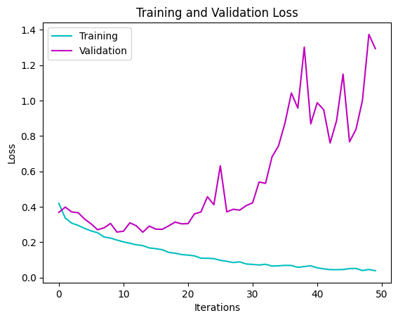

```python
plt.plot(mean_train_loss, 'c', label='Training')
plt.plot(mean_val_loss, 'm', label='Validation')
plt.ylabel('Loss')
plt.xlabel('Iterations')
plt.title('Training and Validation Loss')
plt.legend()
plt.show()
```

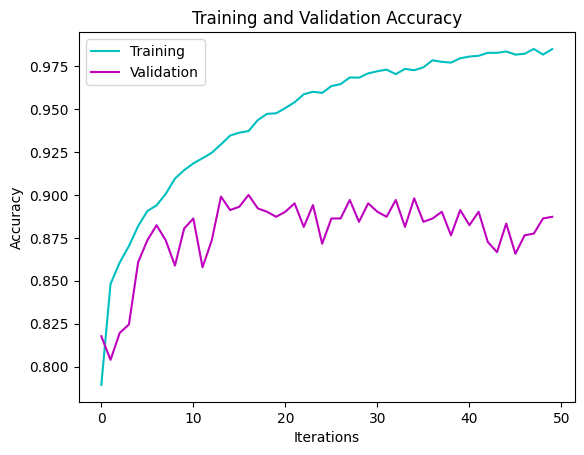

```python
plt.plot(mean_train_acc, 'c', label='Training')
plt.plot(mean_val_acc, 'm', label='Validation')
plt.ylabel('Accuracy')
plt.xlabel('Iterations')
plt.title('Training and Validation Accuracy')
plt.legend()
plt.show()
```

As seen by the graphs, the model is still overfititng. However, the addition of the dropout layer has decreased the amount of overfitting. Originally, the validation loss of the model reached about 1.75, and now it reaches 1.4. However, this is still not ideal, so in the next section I will be adding weight decay to the model to further prevent overfitting.

### Adding Weight Decay

Complexity could be a potential reason the model is overfitting. If the model is too complext, it can prevent it from generalizing well to new data. In order to penalize this complexity, I am going to add weight decay to the model. Weight decay prevents the weights of the model from getting too large, and thus preventing the model from getting too complex. Weight decay is a regularization technique and it is applied during back propagation when updating the model's weights. The values for weight decay range from 1e-5 to 1, so I am going to start with a weight decay of 1e-5 and increase until the model is no longer overfitting.

#### Weight Decay of 1e-5

```python
model_weight_decay_1 = CNN_with_Dropout()
model_weight_decay_1.cuda()
```

```
CNN_with_Dropout(
  (conv1): Conv2d(1, 16, kernel_size=(3, 3), stride=(1, 1), padding=(1, 1))
  (conv2): Conv2d(16, 32, kernel_size=(3, 3), stride=(1, 1), padding=(1, 1))
  (relu): ReLU()
  (sigmoid): Sigmoid()
  (maxpool): MaxPool2d(kernel_size=2, stride=2, padding=0, dilation=1, ceil_mode=False)
  (linear1): Linear(in_features=18432, out_features=120, bias=True)
  (dropout): Dropout(p=0.5, inplace=False)
  (linear2): Linear(in_features=120, out_features=1, bias=True)
)
```

```python
batch_size = 16
learning_rate = 0.001
num_epochs = 50
```

```python
train_dataloader = DataLoader(train_dataset, batch_size=batch_size, shuffle=True)
val_dataloader = DataLoader(val_dataset, batch_size=batch_size, shuffle=False)
test_dataloader = DataLoader(test_dataset, batch_size=batch_size, shuffle=False)
```

The weight decay of 1e-5 is passed in as a parameter to `torch.optim.Adam()`.

```python
loss_function = nn.BCELoss()
optim = torch.optim.Adam(model_weight_decay_1.parameters(), lr = learning_rate, weight_decay=1e-5)
```

```python
mean_train_loss, mean_val_loss, mean_train_acc, mean_val_acc = train_model(model_weight_decay_1, num_epochs, train_dataloader, val_dataloader, optim, loss_function)
```

```
Epoch : 0, Train loss: 0.3843887448310852, Train acc: 0.8126495726495726, Val loss: 0.41335147619247437, Val acc: 0.8147058823529412
Epoch : 5, Train loss: 0.25220492482185364, Train acc: 0.8935612535612536, Val loss: 0.31757301092147827, Val acc: 0.8509803921568627
Epoch : 10, Train loss: 0.20897457003593445, Train acc: 0.9127065527065527, Val loss: 0.25612446665763855, Val acc: 0.8950980392156863
Epoch : 15, Train loss: 0.15192601084709167, Train acc: 0.9401709401709402, Val loss: 0.26777803897857666, Val acc: 0.8950980392156863
Epoch : 20, Train loss: 0.10750667750835419, Train acc: 0.9602279202279203, Val loss: 0.305534303188324, Val acc: 0.8970588235294118
Epoch : 25, Train loss: 0.08789607137441635, Train acc: 0.9685470085470086, Val loss: 0.4104888439178467, Val acc: 0.8715686274509804
Epoch : 30, Train loss: 0.06171378493309021, Train acc: 0.9773219373219373, Val loss: 0.4329772889614105, Val acc: 0.8901960784313725
Epoch : 35, Train loss: 0.04620916023850441, Train acc: 0.981994301994302, Val loss: 0.5924758315086365, Val acc: 0.8921568627450981
Epoch : 40, Train loss: 0.046766411513090134, Train acc: 0.9824501424501425, Val loss: 0.55662602186203, Val acc: 0.8911764705882353
Epoch : 45, Train loss: 0.0321456603705883, Train acc: 0.9879202279202279, Val loss: 0.8494769334793091, Val acc: 0.8931372549019608
```

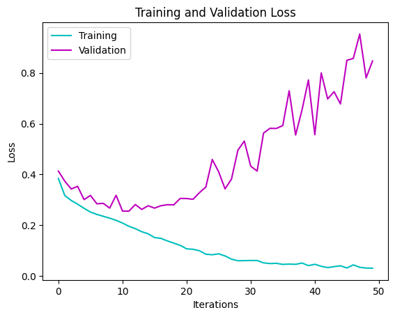

```python
plt.plot(mean_train_loss, 'c', label='Training')
plt.plot(mean_val_loss, 'm', label='Validation')
plt.ylabel('Loss')
plt.xlabel('Iterations')
plt.title('Training and Validation Loss')
plt.legend()
plt.show()
```

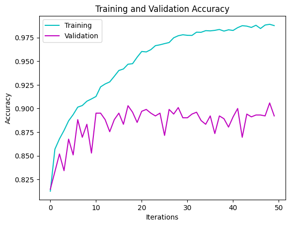

```python
plt.plot(mean_train_acc, 'c', label='Training')
plt.plot(mean_val_acc, 'm', label='Validation')
plt.ylabel('Accuracy')
plt.xlabel('Iterations')
plt.title('Training and Validation Accuracy')
plt.legend()
plt.show()
```

Once again, the model is still overfitting, but not as much as it previously was. The overall validation loss has decreased to about 1. However, I am going to increase the weight decay to further prevent overfitting.

#### Weight Decay of 1e-4

I am now going to define a model with a weight decay of 1e-4.

```python
model_weight_decay_2 = CNN_with_Dropout()
model_weight_decay_2.cuda()
```

```
CNN_with_Dropout(
  (conv1): Conv2d(1, 16, kernel_size=(3, 3), stride=(1, 1), padding=(1, 1))
  (conv2): Conv2d(16, 32, kernel_size=(3, 3), stride=(1, 1), padding=(1, 1))
  (relu): ReLU()
  (sigmoid): Sigmoid()
  (maxpool): MaxPool2d(kernel_size=2, stride=2, padding=0, dilation=1, ceil_mode=False)
  (linear1): Linear(in_features=18432, out_features=120, bias=True)
  (dropout): Dropout(p=0.5, inplace=False)
  (linear2): Linear(in_features=120, out_features=1, bias=True)
)
```

```python
batch_size = 16
learning_rate = 0.001
num_epochs = 50
```

```python
train_dataloader = DataLoader(train_dataset, batch_size=batch_size, shuffle=True)
val_dataloader = DataLoader(val_dataset, batch_size=batch_size, shuffle=False)
test_dataloader = DataLoader(test_dataset, batch_size=batch_size, shuffle=False)
```

```python
loss_function = nn.BCELoss()
optim = torch.optim.Adam(model_weight_decay_2.parameters(), lr = learning_rate, weight_decay=1e-4)
```

```python
mean_train_loss, mean_val_loss, mean_train_acc, mean_val_acc = train_model(model_weight_decay_2, num_epochs, train_dataloader, val_dataloader, optim, loss_function)
```

```
Epoch : 0, Train loss: 0.33660221099853516, Train acc: 0.8411396011396012, Val loss: 0.3721925616264343, Val acc: 0.8323529411764706
Epoch : 5, Train loss: 0.2623153328895569, Train acc: 0.8886609686609687, Val loss: 0.29805344343185425, Val acc: 0.8813725490196078
Epoch : 10, Train loss: 0.21414361894130707, Train acc: 0.9132763532763533, Val loss: 0.2763696312904358, Val acc: 0.888235294117647
Epoch : 15, Train loss: 0.17757047712802887, Train acc: 0.93002849002849, Val loss: 0.2585490345954895, Val acc: 0.8921568627450981
Epoch : 20, Train loss: 0.14853782951831818, Train acc: 0.9414245014245014, Val loss: 0.24691200256347656, Val acc: 0.8921568627450981
Epoch : 25, Train loss: 0.1186879500746727, Train acc: 0.9540740740740741, Val loss: 0.28259050846099854, Val acc: 0.8941176470588236
Epoch : 30, Train loss: 0.09418491274118423, Train acc: 0.9633048433048433, Val loss: 0.3426240086555481, Val acc: 0.8872549019607843
Epoch : 35, Train loss: 0.08042222261428833, Train acc: 0.9687749287749288, Val loss: 0.35097014904022217, Val acc: 0.8921568627450981
Epoch : 40, Train loss: 0.07974103838205338, Train acc: 0.9710541310541311, Val loss: 0.38968634605407715, Val acc: 0.888235294117647
Epoch : 45, Train loss: 0.06878121197223663, Train acc: 0.972991452991453, Val loss: 0.3553101718425751, Val acc: 0.888235294117647
```

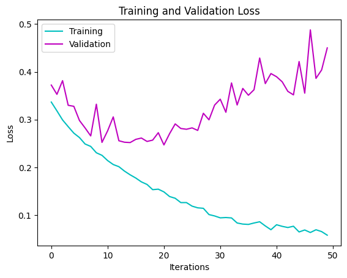

```python
plt.plot(mean_train_loss, 'c', label='Training')
plt.plot(mean_val_loss, 'm', label='Validation')
plt.ylabel('Loss')
plt.xlabel('Iterations')
plt.title('Training and Validation Loss')
plt.legend()
plt.show()
```

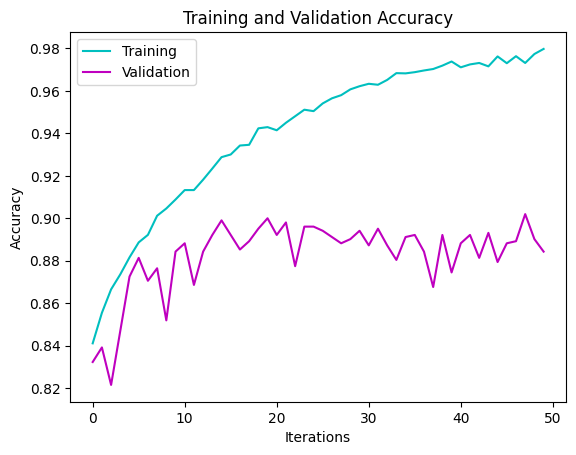

```python
plt.plot(mean_train_acc, 'c', label='Training')
plt.plot(mean_val_acc, 'm', label='Validation')
plt.ylabel('Accuracy')
plt.xlabel('Iterations')
plt.title('Training and Validation Accuracy')
plt.legend()
plt.show()
```

Increasing the weight decay further improves the model and prevents overfitting, as seen by the maximum validation loss of about 0.5. The model is overfitting significantly less than before, however the graphs indicate it is still overfitting, so I am going to increase the weight decay once again.

#### Weight Decay of 1e-3

I am now defining a model with a weight decay of 1e-3.

```python
model_weight_decay_3 = CNN_with_Dropout()
model_weight_decay_3.cuda()
```

```
CNN_with_Dropout(
  (conv1): Conv2d(1, 16, kernel_size=(3, 3), stride=(1, 1), padding=(1, 1))
  (conv2): Conv2d(16, 32, kernel_size=(3, 3), stride=(1, 1), padding=(1, 1))
  (relu): ReLU()
  (sigmoid): Sigmoid()
  (maxpool): MaxPool2d(kernel_size=2, stride=2, padding=0, dilation=1, ceil_mode=False)
  (linear1): Linear(in_features=18432, out_features=120, bias=True)
  (dropout): Dropout(p=0.5, inplace=False)
  (linear2): Linear(in_features=120, out_features=1, bias=True)
)
```

```python
batch_size = 16
learning_rate = 0.001
num_epochs = 50
```

```python
train_dataloader = DataLoader(train_dataset, batch_size=batch_size, shuffle=True)
val_dataloader = DataLoader(val_dataset, batch_size=batch_size, shuffle=False)
test_dataloader = DataLoader(test_dataset, batch_size=batch_size, shuffle=False)
```

```python
loss_function = nn.BCELoss()
optim = torch.optim.Adam(model_weight_decay_3.parameters(), lr = learning_rate, weight_decay=1e-3)
```

```python
mean_train_loss, mean_val_loss, mean_train_acc, mean_val_acc = train_model(model_weight_decay_3, num_epochs, train_dataloader, val_dataloader, optim, loss_function)
```

```
Epoch : 0, Train loss: 0.39321303367614746, Train acc: 0.8078632478632478, Val loss: 0.39631807804107666, Val acc: 0.8294117647058824
Epoch : 5, Train loss: 0.3009459674358368, Train acc: 0.8703133903133903, Val loss: 0.33965104818344116, Val acc: 0.85
Epoch : 10, Train loss: 0.2611691951751709, Train acc: 0.895042735042735, Val loss: 0.27219486236572266, Val acc: 0.8941176470588236
Epoch : 15, Train loss: 0.23251846432685852, Train acc: 0.9072364672364672, Val loss: 0.2641969323158264, Val acc: 0.8980392156862745
Epoch : 20, Train loss: 0.22494052350521088, Train acc: 0.90997150997151, Val loss: 0.24241504073143005, Val acc: 0.9107843137254902
Epoch : 25, Train loss: 0.21197369694709778, Train acc: 0.9144159544159545, Val loss: 0.22841019928455353, Val acc: 0.9166666666666666
Epoch : 30, Train loss: 0.20590098202228546, Train acc: 0.9214814814814815, Val loss: 0.2631755769252777, Val acc: 0.9029411764705882
Epoch : 35, Train loss: 0.19331686198711395, Train acc: 0.9226210826210827, Val loss: 0.22919635474681854, Val acc: 0.9186274509803921
Epoch : 40, Train loss: 0.1881323903799057, Train acc: 0.925014245014245, Val loss: 0.24560993909835815, Val acc: 0.907843137254902
Epoch : 45, Train loss: 0.1794021725654602, Train acc: 0.9276353276353276, Val loss: 0.22578902542591095, Val acc: 0.9088235294117647
```

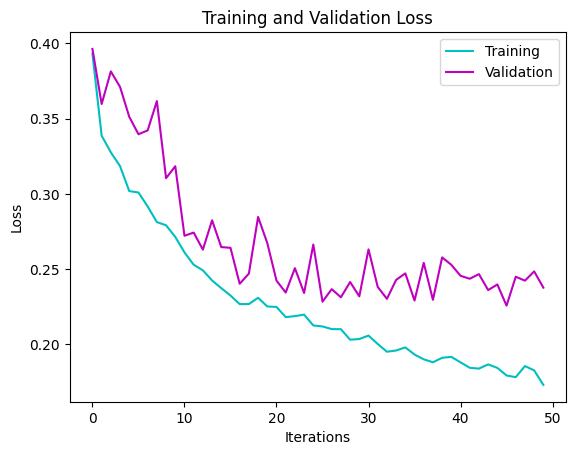

```python
plt.plot(mean_train_loss, 'c', label='Training')
plt.plot(mean_val_loss, 'm', label='Validation')
plt.ylabel('Loss')
plt.xlabel('Iterations')
plt.title('Training and Validation Loss')
plt.legend()
plt.show()
```

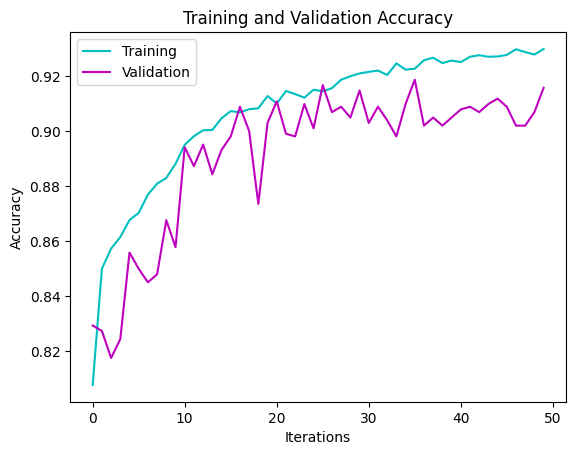

```python
plt.plot(mean_train_acc, 'c', label='Training')
plt.plot(mean_val_acc, 'm', label='Validation')
plt.ylabel('Accuracy')
plt.xlabel('Iterations')
plt.title('Training and Validation Accuracy')
plt.legend()
plt.show()
```

When using a weight decay of 1e-3, the model no longer overfits! This is indicated by the loss graph, in which the validation loss plateaus. In previous graphs, the validation loss increased after approximately 20 epochs, indicating overfitting. Additionally, the accuracy graph shows similar training and validation accuracies, with the validation accuracy also plateauing. Both the validation loss and accuracy stabilize around 30 epochs, signaling that the model is done learning. Therefore, the model does not need to be trained any further, which will be reflected in the next model.

#### Adjusting the Number of Epochs

```python
model_30_epochs = CNN_with_Dropout()
model_30_epochs.cuda()
```

```
CNN_with_Dropout(
  (conv1): Conv2d(1, 16, kernel_size=(3, 3), stride=(1, 1), padding=(1, 1))
  (conv2): Conv2d(16, 32, kernel_size=(3, 3), stride=(1, 1), padding=(1, 1))
  (relu): ReLU()
  (sigmoid): Sigmoid()
  (maxpool): MaxPool2d(kernel_size=2, stride=2, padding=0, dilation=1, ceil_mode=False)
  (linear1): Linear(in_features=18432, out_features=120, bias=True)
  (dropout): Dropout(p=0.5, inplace=False)
  (linear2): Linear(in_features=120, out_features=1, bias=True)
)
```

```python
batch_size = 16
learning_rate = 0.001
num_epochs = 30
```

```python
train_dataloader = DataLoader(train_dataset, batch_size=batch_size, shuffle=True)
val_dataloader = DataLoader(val_dataset, batch_size=batch_size, shuffle=False)
test_dataloader = DataLoader(test_dataset, batch_size=batch_size, shuffle=False)
```

```python
loss_function = nn.BCELoss()
optim = torch.optim.Adam(model_30_epochs.parameters(), lr = learning_rate, weight_decay=1e-3)
```

```python
mean_train_loss, mean_val_loss, mean_train_acc, mean_val_acc = train_model(model_30_epochs, num_epochs, train_dataloader, val_dataloader, optim, loss_function)
```

```
Epoch : 0, Train loss: 0.3946012258529663, Train acc: 0.8095726495726496, Val loss: 0.39218634366989136, Val acc: 0.8254901960784313
Epoch : 5, Train loss: 0.29636338353157043, Train acc: 0.8762393162393163, Val loss: 0.3422672748565674, Val acc: 0.8343137254901961
Epoch : 10, Train loss: 0.25945568084716797, Train acc: 0.8945868945868946, Val loss: 0.3245847225189209, Val acc: 0.8588235294117647
Epoch : 15, Train loss: 0.23624813556671143, Train acc: 0.9050712250712251, Val loss: 0.27150335907936096, Val acc: 0.8892156862745098
Epoch : 20, Train loss: 0.22182568907737732, Train acc: 0.9119088319088319, Val loss: 0.2691706418991089, Val acc: 0.8931372549019608
Epoch : 25, Train loss: 0.2166203260421753, Train acc: 0.9130484330484331, Val loss: 0.24506177008152008, Val acc: 0.9049019607843137
```

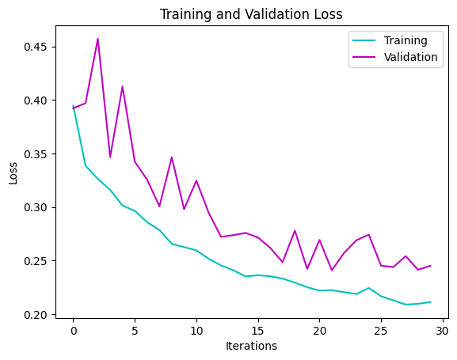

```python
plt.plot(mean_train_loss, 'c', label='Training')
plt.plot(mean_val_loss, 'm', label='Validation')
plt.ylabel('Loss')
plt.xlabel('Iterations')
plt.title('Training and Validation Loss')
plt.legend()
plt.show()
```

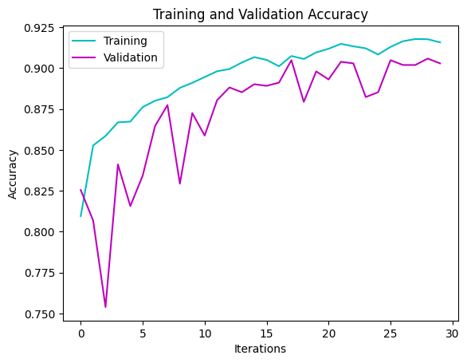

```python
plt.plot(mean_train_acc, 'c', label='Training')
plt.plot(mean_val_acc, 'm', label='Validation')
plt.ylabel('Accuracy')
plt.xlabel('Iterations')
plt.title('Training and Validation Accuracy')
plt.legend()
plt.show()
```

## Testing the Model

It is now time to test the models. I am going to be evaluating each model based on accuracy, precision, sensitivity (recall), specificity, and F1 score. These metrics will be used to determine the best performing model. In the scope of this project, accuracy is the probability the model correctly diagnoses a patient with or without melanoma, precision is the probability a patient diagnosed with melanoma by the model truly has melanoma, sensitivity is the probability a patient with melanoma is diagnosed by the model, specificity is the probability a patient without melanoma will receive a negative diagnosis, and the F1 score combines the precision and recall scores. A confusion matrix is also being calculated for each model, which provides a visual representation of true positive, true negative, false positive, and false negative classifications for each model.

```python
model_names = ['Original', 'Dropout', '1e-5 Weight Decay', '1e-4 Weight Decay', '1e-3 Weight Decay', '30 Epochs']
accuracies = []
precisions = []
recalls = []
specificities = []
f1_scores = []
```

I am defining my testing loop, which consists of forward propagation for each batch.

```python
def test_model(model, test_dataloader):
  predictions = []
  correct_labels = []
  test_acc = 0

  model.eval()
  for idx, batch in enumerate(test_dataloader):
    with torch.no_grad():
      images, labels = batch

      outputs = model.forward(images.to("cuda"))

      # determining how many images are correctly labeled by model
      for i in range(0, len(outputs)):
          output = round(outputs[i].item())
          predictions.append(output)
          label = labels[i].item()
          correct_labels.append(label)
          if output == label:
              test_acc += 1

  test_acc = test_acc / len(test_dataset)
  return test_acc, correct_labels, predictions
```

### Results for Original Model

```python
acc, correct_labels, predictions = test_model(model_original, test_dataloader)
print("Accuracy: ", acc)
accuracies.append(acc)
```

```
Accuracy:  0.903921568627451
```

```python
prec = precision_score(correct_labels, predictions)
print("Precision: ", prec)
precisions.append(prec)
```

```
Precision:  0.9135802469135802
```

```python
rec = recall_score(correct_labels, predictions)
print("Sensitivity/Recall: ", rec)
recalls.append(rec)
```

```
Sensitivity/Recall: 0.888
```

```python
f1 = f1_score(correct_labels, predictions)
print("F1 Score: ", f1)
f1_scores.append(f1)
```

```
F1 Score:  0.9006085192697769
```

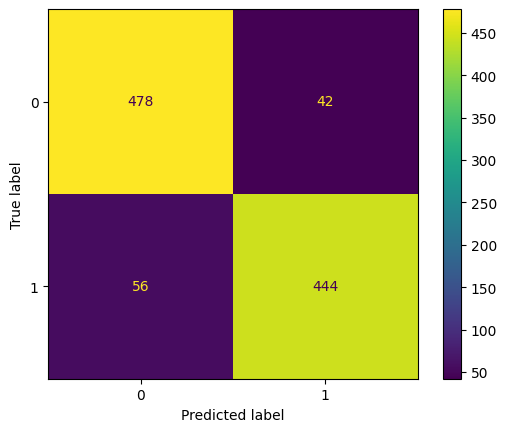

```python
cm = confusion_matrix(correct_labels, predictions)
disp = ConfusionMatrixDisplay(cm)
disp.plot()
plt.show()
```

```python
specificity = 478 / (478 + 42)
print("Specifity: ", specificity)
specificities.append(specificity)
```

```
Specifity:  0.9192307692307692
```

### Results for Model with Dropout

```python
acc, correct_labels, predictions = test_model(model_dropout, test_dataloader)
print("Accuracy: ", acc)
accuracies.append(acc)
```

```
Accuracy:  0.8970588235294118
```

```python
prec = precision_score(correct_labels, predictions)
print("Precision: ", prec)
precisions.append(prec)
```

```
Precision:  0.9140461215932913
```

```python
rec = recall_score(correct_labels, predictions)
print("Sensitivity/Recall: ", rec)
recalls.append(rec)
```

```
Sensitivity/Recall: 0.872
```

```python
f1 = f1_score(correct_labels, predictions)
print("F1 Score: ", f1)
f1_scores.append(f1)
```

```
F1 Score:  0.8925281473899693
```

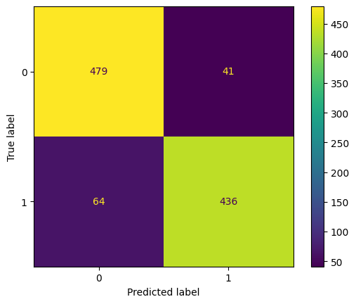

```python
cm = confusion_matrix(correct_labels, predictions)
disp = ConfusionMatrixDisplay(cm)
disp.plot()
plt.show()
```

```python
specificity = 479 / (479 + 41)
print("Specifity: ", specificity)
specificities.append(specificity)
```

```
Specifity:  0.9211538461538461
```

### Results for Model with Weight Decay of 1e-5

```python
acc, correct_labels, predictions = test_model(model_weight_decay_1, test_dataloader)
print("Accuracy: ", acc)
accuracies.append(acc)
```

```
Accuracy:  0.9088235294117647
```

```python
prec = precision_score(correct_labels, predictions)
print("Precision: ", prec)
precisions.append(prec)
```

```
Precision:  0.917864476386037
```

```python
rec = recall_score(correct_labels, predictions)
print("Sensitivity/Recall: ", rec)
recalls.append(rec)
```

```
Sensitivity/Recall: 0.894
```

```python
f1 = f1_score(correct_labels, predictions)
print("F1 Score: ", f1)
f1_scores.append(f1)
```

```
F1 Score:  0.905775075987842
```

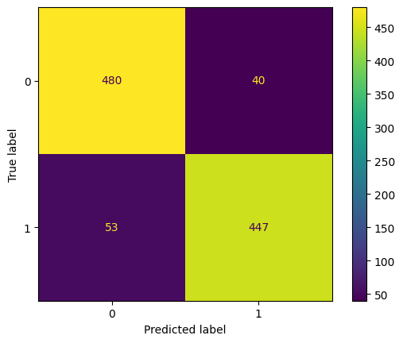

```python
cm = confusion_matrix(correct_labels, predictions)
disp = ConfusionMatrixDisplay(cm)
disp.plot()
plt.show()
```

```python
specificity = 480 / (480 + 40)
print("Specifity: ", specificity)
specificities.append(specificity)
```

```
Specifity:  0.9230769230769231
```

### Results for Model with Weight Decay of 1e-4

```python
acc, correct_labels, predictions = test_model(model_weight_decay_2, test_dataloader)
print("Accuracy: ", acc)
accuracies.append(acc)
```

```
Accuracy:  0.9029411764705882
```

```python
prec = precision_score(correct_labels, predictions)
print("Precision: ", prec)
precisions.append(prec)
```

```
Precision:  0.9368191721132898
```

```python
rec = recall_score(correct_labels, predictions)
print("Sensitivity/Recall: ", rec)
recalls.append(rec)
```

```
Sensitivity/Recall: 0.86
```

```python
f1 = f1_score(correct_labels, predictions)
print("F1 Score: ", f1)
f1_scores.append(f1)
```

```
F1 Score:  0.8967674661105318
```

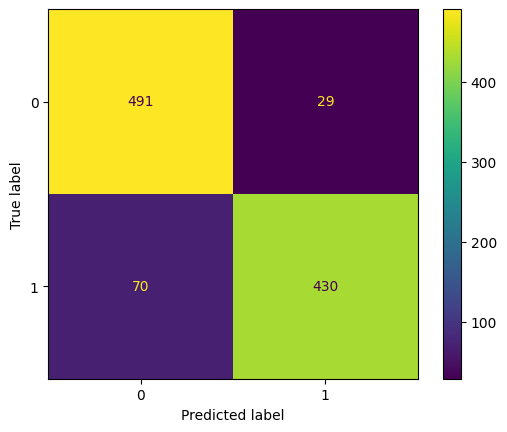

```python
cm = confusion_matrix(correct_labels, predictions)
disp = ConfusionMatrixDisplay(cm)
disp.plot()
plt.show()
```

```python
specificity = 491 / (491 + 29)
print("Specifity: ", specificity)
specificities.append(specificity)
```

```
Specifity:  0.9442307692307692
```

### Results for Model with Weight Decay of 1e-3

```python
acc, correct_labels, predictions = test_model(model_weight_decay_3, test_dataloader)
print("Accuracy: ", acc)
accuracies.append(acc)
```

[output not shown]

```python
prec = precision_score(correct_labels, predictions)
print("Precision: ", prec)
precisions.append(prec)
```

```
Precision:  0.9053497942386831
```

```python
rec = recall_score(correct_labels, predictions)
print("Sensitivity/Recall: ", rec)
recalls.append(rec)
```

```
Sensitivity/Recall: 0.88
```

```python
f1 = f1_score(correct_labels, predictions)
print("F1 Score: ", f1)
f1_scores.append(f1)
```

```
F1 Score:  0.8924949290060852
```

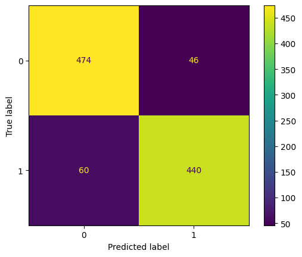

```python
cm = confusion_matrix(correct_labels, predictions)
disp = ConfusionMatrixDisplay(cm)
disp.plot()
plt.show()
```

```python
specificity = 474 / (474 + 46)
print("Specifity: ", specificity)
specificities.append(specificity)
```

```
Specifity:  0.9115384615384615
```